# CAPITAL BIKESHARE ANALYSIS SUMMARY

Data Pandas

2025-03-26

```r
library(ezids)
library(ggplot2)
library(dplyr)
library(readr)
library(tidyr)
library(lubridate)
library(gridExtra)
library(forcats)
library(stringr)
```

#**“Pedaling” Data: Identifying Capital Bikeshare User Trends** Team Data Pandas: Meghan Casey, Raye Oji, Siddardha (Siddu) Reddy, Siddhant Saxena & Siva Kumar #**Abstract**

This study analyzes January 2025 data from Capital Bikeshare to identify high demand stations and temporal usage patterns in the Washington Metropolitan Area, informing strategies to optimize bike rebalancing and dock adjustments. Our analysis involved a deep dive into Capital Bike Share’s usage data, using a variety of visualizations and statistical methods to uncover demand patterns and station utilization by time of day and day of the week.

The project’s goal was to develop actionable insights for prioritizing bike redistribution and dock adjustments, ensuring riders encounter fewer availability issues. We used data visualizations and a variety of sophisticated statistical methods, such as z-tests, correlation analysis, and ANOVA, to accomplish this, identifying temporal demand peaks, evaluating trip duration variability, and uncovering station specific usage patterns critical for operational adjustments. This analysis provides a framework for Capital Bikeshare to enhance resource allocation strategies, balancing efficiency with rider satisfaction, and lays the groundwork for future research integrating multi month datasets to refine seasonal rebalancing protocols.

#**Introduction of the Research Problem**

One day, Siddu was traveling to his favorite Data Science class at George Washington (GW) University in Washington DC. He took the metro for the first leg of his journey. However, after getting off the metro, there was still a ways to reach GW campus. The weather was beautiful, and the cherry blossoms were just starting to bloom, so he planned to use the city’s public bikeshare program Capital Bikeshare to cover the remaining distance. Unfortunately, there were no bikes available at the station. He had to walk the rest of the way, and rushed into class late. Interestingly, the very next day, he noticed a large number of unused Capital Bikeshare bikes docked near his apartment complex.

Siddu’s experience sparked a discussion with his classmates about the availability and distribution of Capital Bikeshare bikes across the city. We realized this could be a meaningful problem to explore further, and that led us to our main research question: What are the most popular bikeshare stations and how does usage vary by time of day and day of the week? The answers to this question could help inform how the Capital Bikeshare program distributes its resources across the DC metropolitan area, enabling it to better serve members of its community like Siddu and his classmates.

#**Background Analysis**

When Washington DC’s Capital Bikeshare program was introduced in 2010, it was the first city-operated bike sharing system in the US. Since then, Capital Bikeshare users have generated millions of rides. Bike use and the placement of docking stations around the city varies widely. DC’s Department of Transportation has undertaken previous research studies to try to ensure equity in the bikesharing program, which have found that the density of bikeshare infrastructure is higher in affluent neighborhoods and areas with tourist attractions (Su, 2019). Previous studies also show that the share of bicycle commuters in the District has grown by 315 percent since 1990 (Johnston, 2014). Together, these two studies show that biking plays an important part in the DC community.

#**Our Dataset**

The variables that were most relevant to our research and analysis were those related to time and location. This includes start time, end time, start location, end location, and the station names. We were able to manipulate data on start and end time to create a new variable labeled “trip duration”, enabling us to measure the length of time of each bike ride. Combining location and duration variables with the start and end times of the rides allowed us to conduct comparisons about bike usage on different days of the week and hours of the day. Manipulating the dates included in the raw dataset to categorical variables such as “weekday” and “weekend” also helped illuminate these trends.

Our decision to analyze the most recently available data had tradeoffs, because it limited our ability to explore trends over a broader stretch of time. For example, we could not explore variance in patterns of usage across different seasons. We intentionally made this choice to prioritize recent information over a more longitudinal dataset because there was such a robust number of observations available for the month of January. Exploring these trends would require combining multiple datasets from Capital Bikeshare’s public repository, and could be a good follow on research project.

Another limitation of our dataset is in the ability to address our interest in demand for Capital Bikeshare bikes. We used the number of bike rides associated with each station to identify the most and least popular locations where the service is being utilized. However, as Siddu’s story shows, bikes are not always available for those who wish to use them. This means that we are not fully capturing the demand for bikes, because those who wished to use Capital Bikeshare but were unable to because no bikes were available are not represented in the dataset.

## 0.1 Lets load the dataset:

We will load rthe dataset and see a few rows.

```r
BikeShare_Data <- data.frame(read.csv("202501-capitalbikeshare-tripdata.csv"))
head(BikeShare_Data, n=5)
```

|  | ride_id | rideable_type | started_at | ended_at | start_station_name | start_station_id | end_station_name | end_station_id | start_lat | start_lng | end_lat | end_lng | member_casual |
| --- | --- | --- | --- | --- | --- | --- | --- | --- | --- | --- | --- | --- | --- |
| 1 | 63DF1EFB0216674C | electric_bike | 2025-01-18 16:14:21.601 | 2025-01-18 16:20:13.231 | 8th & F St NE | 31631 | 1st & K St NE | 31662 | 38.89727 | -76.99475 | 38.90239 | -77.00565 | member |
| 2 | DAD39B0B13A41150 | electric_bike | 2025-01-29 20:36:00.571 | 2025-01-29 20:39:58.943 | Massachusetts Ave & Dupont Circle NW | 31200 | Columbia Rd & Belmont St NW | 31113 | 38.91010 | -77.04440 | 38.92067 | -77.04368 | member |
| 3 | F96FA218286196EC | electric_bike | 2025-01-03 12:17:52.054 | 2025-01-03 12:22:55.910 | Columbia Rd & Belmont St NW | 31113 | Park Rd & Holmead Pl NW | 31602 | 38.92067 | -77.04368 | 38.93080 | -77.03150 | member |
| 4 | 50367789F635AD37 | classic_bike | 2025-01-30 17:34:47.539 | 2025-01-30 17:49:29.391 | New Hampshire Ave & 24th St NW | 31275 | 7th St & Florida Ave NW | 31109 | 38.90176 | -77.05108 | 38.91614 | -77.02200 | member |
| 5 | 074F88EFE803A53C | electric_bike | 2025-01-31 09:37:39.965 | 2025-01-31 09:44:00.375 | Massachusetts Ave & Dupont Circle NW | 31200 | 23rd & E St NW | 31260 | 38.91010 | -77.04440 | 38.89610 | -77.04988 | member |

Let’s see the structure and summary of the variables in the dataset to get an idea about it.

```
## 'data.frame':    285731 obs. of  13 variables:
##  $ ride_id           : chr  "63DF1EFB0216674C" "DAD39B0B13A41150" "F96FA218286196EC" "50367789F635AD37" ...
##  $ rideable_type     : chr  "electric_bike" "electric_bike" "electric_bike" "classic_bike" ...
##  $ started_at        : chr  "2025-01-18 16:14:21.601" "2025-01-29 20:36:00.571" "2025-01-03 12:17:52.054" "2025-01-30 17:34:47.539" ...
##  $ ended_at          : chr  "2025-01-18 16:20:13.231" "2025-01-29 20:39:58.943" "2025-01-03 12:22:55.910" "2025-01-30 17:49:29.391" ...
##  $ start_station_name: chr  "8th & F St NE" "Massachusetts Ave & Dupont Circle NW" "Columbia Rd & Belmont St NW" "New Hampshire Ave & 24th St NW" ...
##  $ start_station_id  : int  31631 31200 31113 31275 31200 31631 31631 31631 31200 31200 ...
##  $ end_station_name  : chr  "1st & K St NE" "Columbia Rd & Belmont St NW" "Park Rd & Holmead Pl NW" "7th St & Florida Ave NW" ...
##  $ end_station_id    : int  31662 31113 31602 31109 31260 31218 31218 31631 31223 31223 ...
##  $ start_lat         : num  38.9 38.9 38.9 38.9 38.9 ...
##  $ start_lng         : num  -77 -77 -77 -77.1 -77 ...
##  $ end_lat           : num  38.9 38.9 38.9 38.9 38.9 ...
##  $ end_lng           : num  -77 -77 -77 -77 -77 ...
##  $ member_casual     : chr  "member" "member" "member" "member" ...
```

```
##    ride_id          rideable_type       started_at          ended_at
##  Length:285731      Length:285731      Length:285731      Length:285731
##  Class :character   Class :character   Class :character   Class :character
##  Mode  :character   Mode  :character   Mode  :character   Mode  :character
##
##
##
##
##  start_station_name start_station_id end_station_name   end_station_id
##  Length:285731      Min.   :30200    Length:285731      Min.   :30200
##  Class :character   1st Qu.:31203    Class :character   1st Qu.:31208
##  Mode  :character   Median :31291    Mode  :character   Median :31289
##                     Mean   :31376                       Mean   :31376
##                     3rd Qu.:31606                       3rd Qu.:31609
##                     Max.   :33200                       Max.   :33200
##                     NA's   :88122                       NA's   :91217
##    start_lat       start_lng         end_lat         end_lng
##  Min.   :38.76   Min.   :-77.39   Min.   :38.75   Min.   :-77.39
##  1st Qu.:38.90   1st Qu.:-77.04   1st Qu.:38.90   1st Qu.:-77.04
##  Median :38.91   Median :-77.03   Median :38.91   Median :-77.03
##  Mean   :38.91   Mean   :-77.03   Mean   :38.91   Mean   :-77.03
##  3rd Qu.:38.92   3rd Qu.:-77.01   3rd Qu.:38.92   3rd Qu.:-77.01
##  Max.   :39.13   Max.   :-76.83   Max.   :39.24   Max.   :-76.65
##                                   NA's   :183     NA's   :183
##  member_casual
##  Length:285731
##  Class :character
##  Mode  :character
##
##
##
##
```

# 1 **Data Preprocessing**

Raw data is often not in the ideal format for analysis, and the Capital Bikeshare dataset is no exception. To ensure meaningful insights, we must clean, transform, and structure the data to align with our analytical needs.

## 1.1 Removing Unwanted Columns and Converting Data Types

```r
BikeShare_Data$end_lat <- NULL
BikeShare_Data$end_lng <- NULL
BikeShare_Data$start_lat <- NULL
BikeShare_Data$start_lng <- NULL
BikeShare_Data$member_casual <- as.factor(BikeShare_Data$member_casual)
str(BikeShare_Data)
```

```
## 'data.frame':    285731 obs. of  9 variables:
##  $ ride_id           : chr  "63DF1EFB0216674C" "DAD39B0B13A41150" "F96FA218286196EC" "50367789F635AD37" ...
##  $ rideable_type     : chr  "electric_bike" "electric_bike" "electric_bike" "classic_bike" ...
##  $ started_at        : chr  "2025-01-18 16:14:21.601" "2025-01-29 20:36:00.571" "2025-01-03 12:17:52.054" "2025-01-30 17:34:47.539" ...
##  $ ended_at          : chr  "2025-01-18 16:20:13.231" "2025-01-29 20:39:58.943" "2025-01-03 12:22:55.910" "2025-01-30 17:49:29.391" ...
##  $ start_station_name: chr  "8th & F St NE" "Massachusetts Ave & Dupont Circle NW" "Columbia Rd & Belmont St NW" "New Hampshire Ave & 24th St NW" ...
##  $ start_station_id  : int  31631 31200 31113 31275 31200 31631 31631 31631 31200 31200 ...
##  $ end_station_name  : chr  "1st & K St NE" "Columbia Rd & Belmont St NW" "Park Rd & Holmead Pl NW" "7th St & Florida Ave NW" ...
##  $ end_station_id    : int  31662 31113 31602 31109 31260 31218 31218 31631 31223 31223 ...
##  $ member_casual     : Factor w/ 2 levels "casual","member": 2 2 2 2 2 2 2 2 2 2 ...
```

## 1.2 Handling Duplicates

There might be some duplicate values in the data. These duplicate values will always be a problem in our analysis. Let’s remove them.

```r
duplicates_count <- sum(duplicated(BikeShare_Data))
duplicates_count
```

```
## [1] 0
```

There are no duplicate values at all! Capital Bikeshare is maintaining it’s data very accurately.

## 1.3 Handling Missing Values

There will difinately be some rows with a lot of missing values. Since our dataset is huge(280000+), we can remove the missing values. Let’s try to identify them, first.

```r
missing_values <- colSums(is.na(BikeShare_Data))
missing_values
```

```
##            ride_id      rideable_type         started_at           ended_at
##                  0                  0                  0                  0
## start_station_name   start_station_id   end_station_name     end_station_id
##                  0              88122                  0              91217
##      member_casual
##                  0
```

There are many missing values in the columns start_station_id, end_station_id. Since the start station and end station details are crucial for our analysis, its better if we remove the rows where the start station and end station are missing.

```r
BikeShare_Data <- BikeShare_Data[!is.na(BikeShare_Data$start_station_id) &
                                 !is.na(BikeShare_Data$end_station_id), ]
colSums(is.na(BikeShare_Data))
```

```
##            ride_id      rideable_type         started_at           ended_at
##                  0                  0                  0                  0
## start_station_name   start_station_id   end_station_name     end_station_id
##                  0                  0                  0                  0
##      member_casual
##                  0
```

## 1.4 Filtering Rides

There are a few rides which started in 31st Dec 2024 but ended on 1st Jan 2025. We will remove those rows and then put them in an order according to the time they were started at.

```r
BikeShare_Data <- BikeShare_Data[BikeShare_Data$started_at >= "2025-01-01", ]
BikeShare_Data$started_at <- as.POSIXct(BikeShare_Data$started_at)
BikeShare_Data$ended_at <- as.POSIXct(BikeShare_Data$ended_at)

BikeShare_Data <- BikeShare_Data[order(BikeShare_Data$started_at), ]
nrow(BikeShare_Data)
```

```
## [1] 166757
```

We have created a few new columns named “trip_duration”, which will be helpful for future analysis. Also, we removed the outliers.

```r
BikeShare_Data$trip_duration <- as.numeric(difftime(BikeShare_Data$ended_at,
                                                    BikeShare_Data$started_at,
                                                    units = "mins"))

BikeShare_Data$hour_of_day <- format(BikeShare_Data$started_at, "%H")

BikeShare_Data$day_of_week <- weekdays(BikeShare_Data$started_at)

BikeShare_Data$day_of_week <- factor(BikeShare_Data$day_of_week,
                                     levels = c("Monday", "Tuesday", "Wednesday",
                                                "Thursday", "Friday", "Saturday", "Sunday"),
                                     ordered = TRUE)

BikeShare_Data <- BikeShare_Data[BikeShare_Data$trip_duration > 0 & BikeShare_Data$trip_duration < 720,]
```

## 1.5 Removing Outliers

#**Exploratory Data Analysis**

Exploratory Data Analysis (EDA) is an important step before we move into advanced data testing. Through visualizations and summary statistics, EDA helps us understand the data we are working with and allows us to identify key relationships. Insights on ride patterns, peak usage times, and station popularity, enable data-driven decision-making on the Capital Bikeshare program that can benefit its users across DC.

#*Time Oriented EDA*

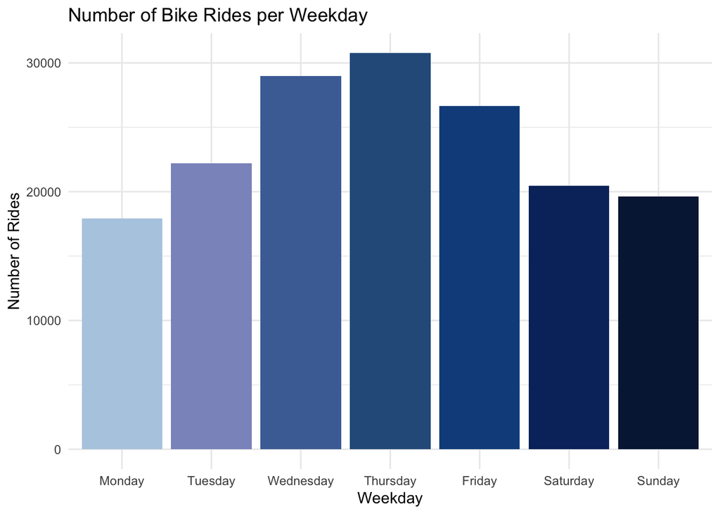

More people are using Capital Bikeshare during the week than they over the weekend, which makes sense given the earlier research on the rapid growth of the number of bicycle commuters in the city.

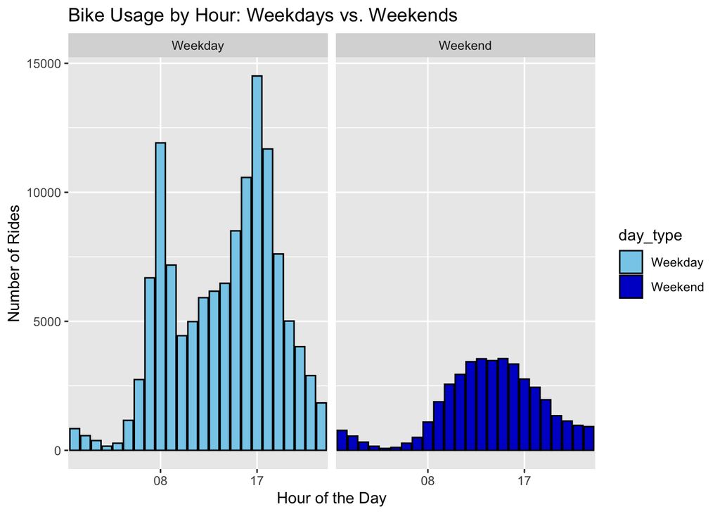

[output not shown]

[output cut: 240 more lines]

[output not shown]

#*Location Oriented EDA*

We are also interested in which locations are the most popular. Since each bike ride is associated with two location variables in our dataset (start location and end location) we can analyze them individually and jointly.

The top five most popular start stations are located at New Hampshire Avenue and T St. NW, Columbus Circle/Union Station, 15th and P St. NW, the Eastern Market Metro, and 14th and V St. NW.

The top five most popular end stations are located at Columbus Circle/Union Station, New Hampshire Avenue and T St. NW, 15th and P St. NW, 5th and K St. NW.

There is a lot overlap between the most popular start and end stations, as there is if we combine these variables to look at the most popular stations overall.

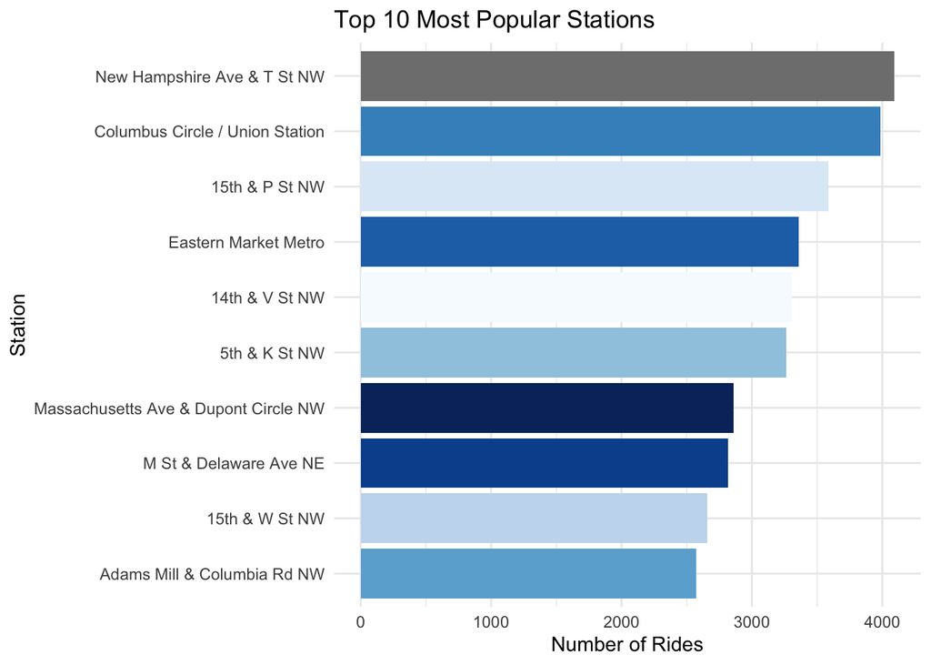

```r
#plotting most popular stations by combined start and stop measure.
combined_station_data <- BikeShare_Data %>%
  gather(key = "station_type", value = "station_name", start_station_name, end_station_name) %>%
  count(station_name, sort = TRUE) %>%
  top_n(10, n)  # Top 10 stations

# Plot Combined Start and End Stations
ggplot(combined_station_data, aes(x = reorder(station_name, n), y = n, fill = station_name)) +
  geom_bar(stat = "identity") +
  coord_flip() +
  labs(title = "Top 10 Most Popular Stations",
       x = "Station",
       y = "Number of Rides") +
   guides(fill = "none") +
  theme_minimal() +
  scale_fill_manual(values = scales::brewer_pal(palette = "Blues")(10))
```

This data is most useful if we contrast it with the least-used stations.

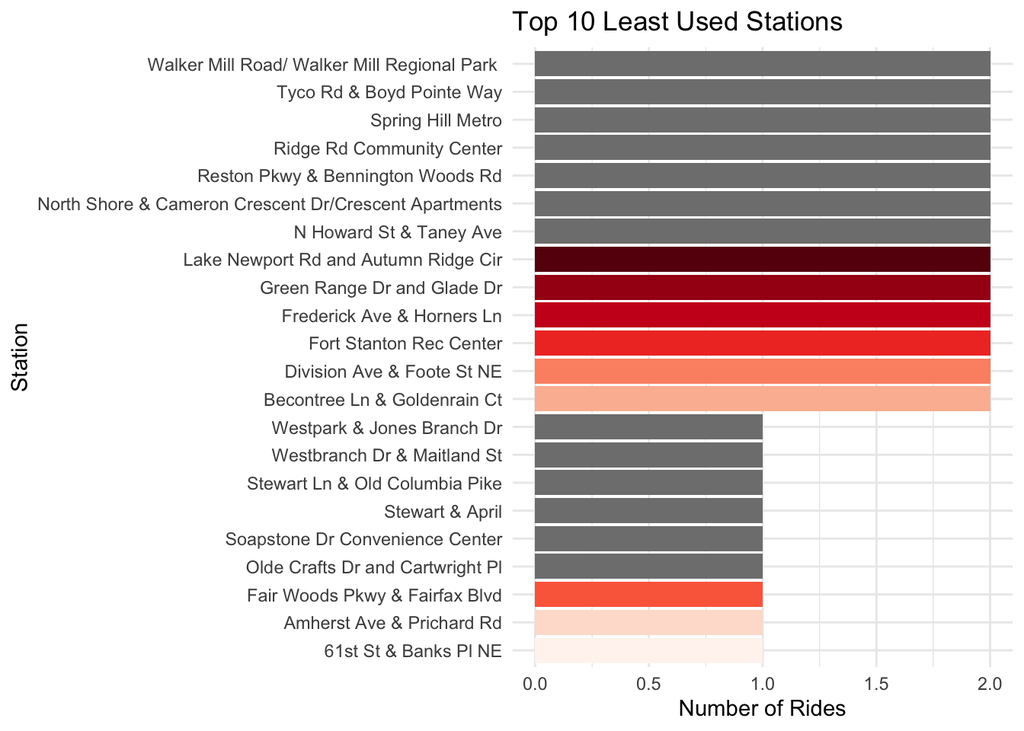

```r
# Finding least popular stations by combined start and stop measure
least_combined_station_data <- BikeShare_Data %>%
  gather(key = "station_type", value = "station_name", start_station_name, end_station_name) %>%
  count(station_name, sort = TRUE) %>%
  top_n(-10, n)  # Get bottom 10 stations

# Plot Combined Least Used Start and End Stations
ggplot(least_combined_station_data, aes(x = reorder(station_name, n), y = n, fill = station_name)) +
  geom_bar(stat = "identity") +
  coord_flip() +
  labs(title = "Top 10 Least Used Stations",
       x = "Station",
       y = "Number of Rides") +
  guides(fill = "none") +
  theme_minimal() +
  scale_fill_manual(values = scales::brewer_pal(palette = "Reds")(24))
```

Using the same methodology of combining the location data for start and stations and ranking them by least usage reveals a massive difference. Some of the least used BikeShare stations have only a single ride associated with them, while the most frequently used ones have thousands.

#*Trip Duration EDA*

The length of time users spend on bike rides is indirectly related to our key question, because it is related to the data on locations. Shorter bike trip durations indicate shorter physical distances, meaning users are more likely to use stations that are located close together.

Our initial research found that the mean trip duration for Capital Bikeshare users was 11 minutes, with a standard deviation of 14.9. The sample size for this test (having removed outliers in our initial data processing) was 166,661.

However, these numbers are odd because the standard deviation is higher than the mean. This indicates a lot of variable and dispersion in our data, some values are much higher and much lower than the mean. Our confidence interval was quite small—we can be 95% confident that the population parameter of the mean falls between 10.96 and 11.11 minutes. Taken together, these measures suggest outliers are having an impact on this measure.

We tried removing very small outliers (those under a minute), because we thought these might be the result of technical errors or faulty bikes. However, that did not change the mean and SD. Then, we tried removing high value outliers (those over an hour). This made a lot more sense.

#*After the EDA, did your questions change? If so, how?*

These analyses helped us reading temporal patterns, user preferences, and trip-behavior variability into rebalancing logic. Instead of a static high traffic approach, the focus is on predictive, adaptive resource allocation which ensures bikes and docks meet real time demand while catering to rider demographics. This evolution directly addresses the EDA’s revelation that station usage is not just location dependent but influenced by time, user type, and bike functionality, enabling a more actionable and efficient operational strategy.

#*Sources*

Johnston, K. (2014). Beyond Urban Planning: The Economics of Capital Bikeshare. https://gppreview.com/2014/04/07/beyond-urban-planning-the-economics-of-capital-bikeshare/.

Su, Y., & Wang, R. (2019). Three ways bikeshare can counteract, not reinforce, DC’s disparities.https://www.urban.org/urban-wire/three-ways-bikeshare-can-counteract-not-reinforce-dcs-disparities.

```